# Missing Data

Missing data with be in every realistic dataset.

```python
import pandas as pd
import numpy as np
data = pd.read_csv('./samples_rw/missing/california_restaurants.csv')
df = pd.read_csv('./samples_rw/missing/example_1.csv', index_col='date')
```

```python
df
```

| date | Stock_A | Stock_B | Stock_C |
| --- | --- | --- | --- |
| 2023-01-01 | 20.0 | NaN | 19.0 |
| 2023-01-02 | 465.0 | NaN | NaN |
| 2023-01-03 | NaN | 14.0 | 86.0 |
| 2023-01-04 | NaN | 25.0 | 19.0 |
| 2023-01-05 | 25.0 | 9.0 | NaN |
| 2023-01-06 | 75.0 | 75.0 | 19.0 |

# Easy Plot

Easy method of plot in pandas:

```python
 # df.plot()
```

# isna ( )

This method shows me the series with boolean records of missed values. (True means is missed).

This is how we detecting missing values from the column.

```python
df['Stock_A'].isna()
```

```
date
2023-01-01    False
2023-01-02    False
2023-01-03     True
2023-01-04     True
2023-01-05    False
2023-01-06    False
Name: Stock_A, dtype: bool
```

Let's print all rows from dataframe with missing values in the column 'Stock_A:

we applied condition to column A , and shown records from the database.

## find specific column

```python
# show me empty records for the colummn A
df.loc[df.Stock_A.isna()]
```

| date | Stock_A | Stock_B | Stock_C |
| --- | --- | --- | --- |
| 2023-01-03 | NaN | 14.0 | 86.0 |
| 2023-01-04 | NaN | 25.0 | 19.0 |

```python
# show me empty records for column B
df.loc[df.Stock_B.isna()]
```

| date | Stock_A | Stock_B | Stock_C |
| --- | --- | --- | --- |
| 2023-01-01 | 20.0 | NaN | 19.0 |
| 2023-01-02 | 465.0 | NaN | NaN |

This is the same approach to any column we would like to play with:

```python
df.loc[df.Stock_C.isna()]
```

| date | Stock_A | Stock_B | Stock_C |
| --- | --- | --- | --- |
| 2023-01-02 | 465.0 | NaN | NaN |
| 2023-01-05 | 25.0 | 9.0 | NaN |

## find any column with nan

I have received the matrix of series for the missing values:

```python
df.isna()
```

| date | Stock_A | Stock_B | Stock_C |
| --- | --- | --- | --- |
| 2023-01-01 | False | True | False |
| 2023-01-02 | False | True | True |
| 2023-01-03 | True | False | False |
| 2023-01-04 | True | False | False |
| 2023-01-05 | False | False | True |
| 2023-01-06 | False | False | False |

# notna( )

Show me records with NOT missed value. True == the value is not missed.

```python
# True when the value is not NaN
df.Stock_A.notna()
```

```
date
2023-01-01     True
2023-01-02     True
2023-01-03    False
2023-01-04    False
2023-01-05     True
2023-01-06     True
Name: Stock_A, dtype: bool
```

As above we need to grab only not missed values from the columns A :

We filtered data with the stock A to show the records with no missing values.

```python
# show records of column A which are not NaN
df[df.Stock_A.notna()]
```

| date | Stock_A | Stock_B | Stock_C |
| --- | --- | --- | --- |
| 2023-01-01 | 20.0 | NaN | 19.0 |
| 2023-01-02 | 465.0 | NaN | NaN |
| 2023-01-05 | 25.0 | 9.0 | NaN |
| 2023-01-06 | 75.0 | 75.0 | 19.0 |

even if we add the value to NaN the computer does not know how is the NaN, so the value cannot be added.

The numeric values added 100 , but NaN is not changeable.

```python
# the NaN value will not be changed
df.Stock_A + 100
```

```
date
2023-01-01    120.0
2023-01-02    565.0
2023-01-03      NaN
2023-01-04      NaN
2023-01-05    125.0
2023-01-06    175.0
Name: Stock_A, dtype: float64
```

However, changing the NaN value to the zeto does not make a sense in the stock market. This could only missinterpret data, as previously was not noted stocj price equal to zero. The same results will be with adding two stocks together, having NaN values.

**This is a called as propagation of missing values**

```python
df.Stock_A + df.Stock_B
```

```
date
2023-01-01      NaN
2023-01-02      NaN
2023-01-03      NaN
2023-01-04      NaN
2023-01-05     34.0
2023-01-06    150.0
dtype: float64
```

First, let's find the all missing values from the dataframe: it shows that in some columns we have missing values.

```python
data.info()
```

```
<class 'pandas.core.frame.DataFrame'>
RangeIndex: 1273 entries, 0 to 1272
Data columns (total 18 columns):
 #   Column             Non-Null Count  Dtype
---  ------             --------------  -----
 0   Yelp URL           1273 non-null   object
 1   Name               1273 non-null   object
 2   Street Address     1273 non-null   object
 3   Zip Code           1259 non-null   float64
 4   City               1263 non-null   object
 5   State              1259 non-null   object
 6   Price Range        1067 non-null   object
 7   Phone              1196 non-null   object
 8   Rating             1270 non-null   float64
 9   Number of Reviews  1270 non-null   float64
 10  Website            974 non-null    object
 11  Menu Link          591 non-null    object
 12  Image 1            1268 non-null   object
 13  Image 2            1262 non-null   object
 14  Image 3            1255 non-null   object
 15  Category 1         1273 non-null   object
 16  Category 2         1004 non-null   object
 17  Category 3         668 non-null    object
dtypes: float64(3), object(15)
memory usage: 179.1+ KB
```

Secondly, we need to make a decision: should we delete the missing value record / row?

For example, the image or categories columns are less important than Zip code or price range. So, I am focuse what is important for me.

```python
data.dropna(subset='Zip Code').shape
```

```
(1259, 18)
```

Also, I can state that more columns are important in the analyses: so, I must have Zip Code, Name and Price:

It means these columns must have full records in the rows.

Typicaly, I am adding to the subnet columns from which I do not want to loose any full record during cleaning process.

```python
data.dropna(subset=['Zip Code', 'Name', 'Price Range', 'Rating']).shape
```

```
(1055, 18)
```

```python
data.dropna(subset=['Zip Code', 'City']).shape
```

```
(1259, 18)
```

## How Condition of dropna

How : describes the condition how the NaNs must be dropped.

All = drop the rows where both columns match the conditions of NaN.

Any = drop the rows if any selected column is NaN.

ANY is the default value.

Attribute with the condition for dropping process: any , all ...

```python
# all - harder condition to meet
data.dropna(subset=['Zip Code', 'City'], how='all').shape
```

```
(1263, 18)
```

```python
# easier condition to meet
data.dropna(subset=['Zip Code', 'City'], how='any').shape
```

```
(1259, 18)
```

First drop all rows that match Zip Code and City condition (NaN) , secondly remove rows that much any condition to Name, Proce and Rating.

Removing data by conditions, is more accurate than dropping everything with NaNs values.

```python
data.dropna(subset=['Zip Code', 'City'], how='all').dropna(subset=['Name', 'Price Range', 'Rating'], how='any').shape
```

```
(1059, 18)
```

## Drop Columns

Axis=1 attribute allows to drop the columns:

```python
df
```

| date | Stock_A | Stock_B | Stock_C |
| --- | --- | --- | --- |
| 2023-01-01 | 20.0 | NaN | 19.0 |
| 2023-01-02 | 465.0 | NaN | NaN |
| 2023-01-03 | NaN | 14.0 | 86.0 |
| 2023-01-04 | NaN | 25.0 | 19.0 |
| 2023-01-05 | 25.0 | 9.0 | NaN |
| 2023-01-06 | 75.0 | 75.0 | 19.0 |

In the example below I have dropped all columns as each of them include the NaN value(s).

```python
df.dropna(axis=1)
```

| date |
| --- |
| 2023-01-01 |
| 2023-01-02 |
| 2023-01-03 |
| 2023-01-04 |
| 2023-01-05 |
| 2023-01-06 |

# dropna ( )

## delete rows with missed value

The most brute approach to remove any row / record with the missing value(s).

```python
data.dropna().shape
```

```
(342, 18)
```

Dropping that records is too much (almost always).

Therefore, I need to decide, what is important for me and what records I would like to leave in the dataframe.

# isnull ( ) - notnull ( )

Older approaches and not longer recommended to use in pandas. They are identical to isna and notnam but people stopped usiing them in the reason of new method introduction.

# fillna ( )

This method fils selected value in the NaN(s) record.

```python
# filled 0 in the NaNs
df.fillna(0)
```

| date | Stock_A | Stock_B | Stock_C |
| --- | --- | --- | --- |
| 2023-01-01 | 20.0 | 0.0 | 19.0 |
| 2023-01-02 | 465.0 | 0.0 | 0.0 |
| 2023-01-03 | 0.0 | 14.0 | 86.0 |
| 2023-01-04 | 0.0 | 25.0 | 19.0 |
| 2023-01-05 | 25.0 | 9.0 | 0.0 |
| 2023-01-06 | 75.0 | 75.0 | 19.0 |

I can replace the NaNs with the string.

```python
df.fillna('not available')
```

| date | Stock_A | Stock_B | Stock_C |
| --- | --- | --- | --- |
| 2023-01-01 | 20.0 | not available | 19.0 |
| 2023-01-02 | 465.0 | not available | not available |
| 2023-01-03 | not available | 14.0 | 86.0 |
| 2023-01-04 | not available | 25.0 | 19.0 |
| 2023-01-05 | 25.0 | 9.0 | not available |
| 2023-01-06 | 75.0 | 75.0 | 19.0 |

# ffill ( ) forward

Forward filled value in the columns. It automaticaly forwards previous value in place of NaNs.

It filled value by forward, so the column B still is NaNs as no value is given to be forwarded.

Coumn C - filled value frm the historical record, as first row in this example.

```python
df.ffill()
```

| date | Stock_A | Stock_B | Stock_C |
| --- | --- | --- | --- |
| 2023-01-01 | 20.0 | NaN | 19.0 |
| 2023-01-02 | 465.0 | NaN | 19.0 |
| 2023-01-03 | 465.0 | 14.0 | 86.0 |
| 2023-01-04 | 465.0 | 25.0 | 19.0 |
| 2023-01-05 | 25.0 | 9.0 | 19.0 |
| 2023-01-06 | 75.0 | 75.0 | 19.0 |

# bfill ( )

Back fill function , to fill the value in backward.

```python
df.bfill()
```

| date | Stock_A | Stock_B | Stock_C |
| --- | --- | --- | --- |
| 2023-01-01 | 20.0 | 14.0 | 19.0 |
| 2023-01-02 | 465.0 | 14.0 | 86.0 |
| 2023-01-03 | 25.0 | 14.0 | 86.0 |
| 2023-01-04 | 25.0 | 25.0 | 19.0 |
| 2023-01-05 | 25.0 | 9.0 | 19.0 |
| 2023-01-06 | 75.0 | 75.0 | 19.0 |

## limit in data filling

I can apply the limit in the filling data, so not more that one record forward or backward.

```python
df
```

| date | Stock_A | Stock_B | Stock_C |
| --- | --- | --- | --- |
| 2023-01-01 | 20.0 | NaN | 19.0 |
| 2023-01-02 | 465.0 | NaN | NaN |
| 2023-01-03 | NaN | 14.0 | 86.0 |
| 2023-01-04 | NaN | 25.0 | 19.0 |
| 2023-01-05 | 25.0 | 9.0 | NaN |
| 2023-01-06 | 75.0 | 75.0 | 19.0 |

```python
df.bfill(limit=1)
```

| date | Stock_A | Stock_B | Stock_C |
| --- | --- | --- | --- |
| 2023-01-01 | 20.0 | NaN | 19.0 |
| 2023-01-02 | 465.0 | 14.0 | 86.0 |
| 2023-01-03 | NaN | 14.0 | 86.0 |
| 2023-01-04 | 25.0 | 25.0 | 19.0 |
| 2023-01-05 | 25.0 | 9.0 | 19.0 |
| 2023-01-06 | 75.0 | 75.0 | 19.0 |

Both conditions are possible: one day limit backward, one day limit forward.

```python
df.bfill(limit=1).ffill(limit=1)
```

| date | Stock_A | Stock_B | Stock_C |
| --- | --- | --- | --- |
| 2023-01-01 | 20.0 | NaN | 19.0 |
| 2023-01-02 | 465.0 | 14.0 | 86.0 |
| 2023-01-03 | 465.0 | 14.0 | 86.0 |
| 2023-01-04 | 25.0 | 25.0 | 19.0 |
| 2023-01-05 | 25.0 | 9.0 | 19.0 |
| 2023-01-06 | 75.0 | 75.0 | 19.0 |

## filling NaN the average value

Sometimes we would like use an average to fill the gap in the missing records:

I this way we have got the averages inside the empty (NaNs) cells.

```python
df.fillna(df.mean())
```

| date | Stock_A | Stock_B | Stock_C |
| --- | --- | --- | --- |
| 2023-01-01 | 20.00 | 30.75 | 19.00 |
| 2023-01-02 | 465.00 | 30.75 | 35.75 |
| 2023-01-03 | 146.25 | 14.00 | 86.00 |
| 2023-01-04 | 146.25 | 25.00 | 19.00 |
| 2023-01-05 | 25.00 | 9.00 | 35.75 |
| 2023-01-06 | 75.00 | 75.00 | 19.00 |

The mean values applies to the columns.

```python
# check if these were averages
df.mean() # default axis = 0
```

```
Stock_A    146.25
Stock_B     30.75
Stock_C     35.75
dtype: float64
```

Means as the value of rows:

```python
df.mean(axis='columns')
# df.mean(axis= 1)
```

```
date
2023-01-01     19.500000
2023-01-02    465.000000
2023-01-03     50.000000
2023-01-04     22.000000
2023-01-05     17.000000
2023-01-06     56.333333
dtype: float64
```

All statistics functions work in the same way: axis = 1, is the columns agregations. It means that values from selected row from each column is agregated (computed).

# where ( )

Where function can be used to agregate the rows (take row values and if any is NaN , fill the average from columns for this specific row):

notna() - matrix with True where the value exist and False when does not

mean(axis=1) - average aggregated form row

Do you want to go by rows or by columns? 🇰

axis=0 - go by columns per each row from Col1 to Coln

in short: if logical test (part 1 ) validate to False, put the value (part 2) , in the order of (part 3).

```python
# where( detect all non NAN value, replace by this value , )
df.where(df.notna() ,df.mean(axis=1) , axis=0)
```

| date | Stock_A | Stock_B | Stock_C |
| --- | --- | --- | --- |
| 2023-01-01 | 20.0 | 19.5 | 19.0 |
| 2023-01-02 | 465.0 | 465.0 | 465.0 |
| 2023-01-03 | 50.0 | 14.0 | 86.0 |
| 2023-01-04 | 22.0 | 25.0 | 19.0 |
| 2023-01-05 | 25.0 | 9.0 | 17.0 |
| 2023-01-06 | 75.0 | 75.0 | 19.0 |

```python
df.notna()
```

| date | Stock_A | Stock_B | Stock_C |
| --- | --- | --- | --- |
| 2023-01-01 | True | False | True |
| 2023-01-02 | True | False | False |
| 2023-01-03 | False | True | True |
| 2023-01-04 | False | True | True |
| 2023-01-05 | True | True | False |
| 2023-01-06 | True | True | True |

## replace methods

```python
df
```

| date | Stock_A | Stock_B | Stock_C |
| --- | --- | --- | --- |
| 2023-01-01 | 20.0 | NaN | 19.0 |
| 2023-01-02 | 465.0 | NaN | NaN |
| 2023-01-03 | NaN | 14.0 | 86.0 |
| 2023-01-04 | NaN | 25.0 | 19.0 |
| 2023-01-05 | 25.0 | 9.0 | NaN |
| 2023-01-06 | 75.0 | 75.0 | 19.0 |

Replace: I am going to replace all NaNs values by zero:

```python
A = df.replace(np.nan, 0)
A
```

| date | Stock_A | Stock_B | Stock_C |
| --- | --- | --- | --- |
| 2023-01-01 | 20.0 | 0.0 | 19.0 |
| 2023-01-02 | 465.0 | 0.0 | 0.0 |
| 2023-01-03 | 0.0 | 14.0 | 86.0 |
| 2023-01-04 | 0.0 | 25.0 | 19.0 |
| 2023-01-05 | 25.0 | 9.0 | 0.0 |
| 2023-01-06 | 75.0 | 75.0 | 19.0 |

Divided by zero give infinity. Therefore replace function is handy to sort it out. (in calculator division by zero is undefined).

```python
A['div'] = A.Stock_A / A.Stock_B
A
```

| date | Stock_A | Stock_B | Stock_C | div |
| --- | --- | --- | --- | --- |
| 2023-01-01 | 20.0 | 0.0 | 19.0 | inf |
| 2023-01-02 | 465.0 | 0.0 | 0.0 | inf |
| 2023-01-03 | 0.0 | 14.0 | 86.0 | 0.000000 |
| 2023-01-04 | 0.0 | 25.0 | 19.0 | 0.000000 |
| 2023-01-05 | 25.0 | 9.0 | 0.0 | 2.777778 |
| 2023-01-06 | 75.0 | 75.0 | 19.0 | 1.000000 |

Therefore, we can replace infinity records with NaN using numpy and replace function.

So, now we have NaN instead of inf, which cannot be captured by SQL. Therefore in SQL NaN automatically can be mapped to null, but inf will not be!

```python
A.replace(np.inf, np.nan)
```

| date | Stock_A | Stock_B | Stock_C | div |
| --- | --- | --- | --- | --- |
| 2023-01-01 | 20.0 | 0.0 | 19.0 | NaN |
| 2023-01-02 | 465.0 | 0.0 | 0.0 | NaN |
| 2023-01-03 | 0.0 | 14.0 | 86.0 | 0.000000 |
| 2023-01-04 | 0.0 | 25.0 | 19.0 | 0.000000 |
| 2023-01-05 | 25.0 | 9.0 | 0.0 | 2.777778 |
| 2023-01-06 | 75.0 | 75.0 | 19.0 | 1.000000 |

# Interpret missing values

```python
df
```

| date | Stock_A | Stock_B | Stock_C |
| --- | --- | --- | --- |
| 2023-01-01 | 20.0 | NaN | 19.0 |
| 2023-01-02 | 465.0 | NaN | NaN |
| 2023-01-03 | NaN | 14.0 | 86.0 |
| 2023-01-04 | NaN | 25.0 | 19.0 |
| 2023-01-05 | 25.0 | 9.0 | NaN |
| 2023-01-06 | 75.0 | 75.0 | 19.0 |

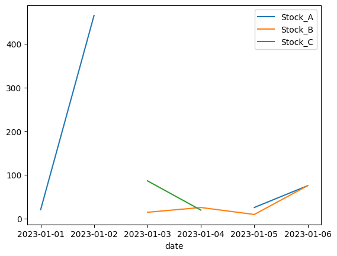

```python
df.plot()
```

Let's fill the data to keep continueity of the data:

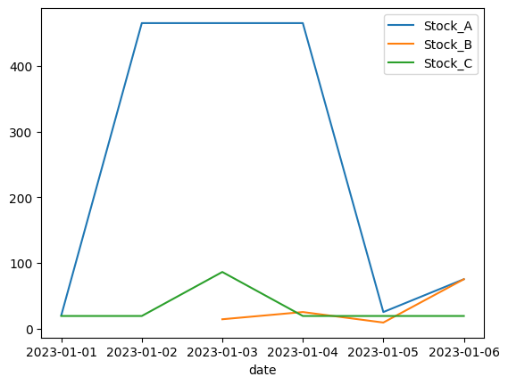

```python
df.ffill().plot()
```

# interpolate ( )

## Interpolation as closing broken lines

The first chart shows the missing data. Second graph shows filled the same data as extended.

Next option we have got interpolation, which is connecting broken lines on the graph.

```python
df.interpolate()
```

| date | Stock_A | Stock_B | Stock_C |
| --- | --- | --- | --- |
| 2023-01-01 | 20.000000 | NaN | 19.0 |
| 2023-01-02 | 465.000000 | NaN | 52.5 |
| 2023-01-03 | 318.333333 | 14.0 | 86.0 |
| 2023-01-04 | 171.666667 | 25.0 | 19.0 |
| 2023-01-05 | 25.000000 | 9.0 | 19.0 |
| 2023-01-06 | 75.000000 | 75.0 | 19.0 |

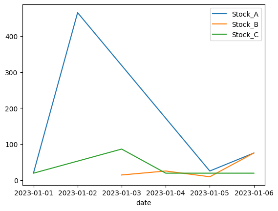

```python
df.interpolate().plot()
```

We can interpolate in the different ways using argument of interpolation:

- linear
- time
- index
- values
- nearest
- ffill / pad
- backfill / bfill
- polynomia
- spline and more SciPy methods

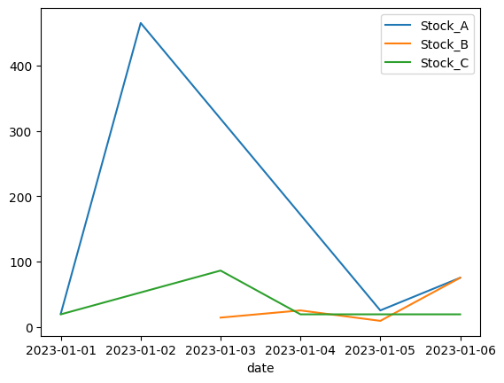

```python
df.interpolate(method='linear').plot()
```